# Lab 6

Author

Norma Marshall

# Lab 06 - Text Mining

# Set up packages

You should load in dplyr, (or data.table if you want to work that way), ggplot2 and tidytext. If you don’t already have tidytext then you can install

```r
library(tidyverse)
library(tidytext)
library(readr)
```

## read in Medical Transcriptions

Loading in reference transcription samples from https://www.mtsamples.com/

```r
mt_samples <- read_csv("https://raw.githubusercontent.com/USCbiostats/data-science-data/master/00_mtsamples/mtsamples.csv")
```

```
──────────────────────────────────────────────────────── Delimiter: "," chr
(5): description, medical_specialty, sample_name, transcription, keywords dbl
(1): ...1
```

```r
mt_samples <- mt_samples %>%
  select(description, medical_specialty, transcription)

head(mt_samples)
```

```
# A tibble: 6 × 3
  description                                    medical_specialty transcription
  <chr>                                          <chr>             <chr>
1 A 23-year-old white female presents with comp… Allergy / Immuno… "SUBJECTIVE:…
2 Consult for laparoscopic gastric bypass.       Bariatrics        "PAST MEDICA…
3 Consult for laparoscopic gastric bypass.       Bariatrics        "HISTORY OF …
4 2-D M-Mode. Doppler.                           Cardiovascular /… "2-D M-MODE:…
5 2-D Echocardiogram                             Cardiovascular /… "1.  The lef…
6 Morbid obesity.  Laparoscopic antecolic anteg… Bariatrics        "PREOPERATIV…
```

# Question 1: What specialties do we have?

We can use count() from dplyr to figure out how many different catagories do we have? Are these catagories related? overlapping? evenly distributed?

```r
specialty <-mt_samples %>%
  count(medical_specialty, sort = TRUE)

head(specialty)
```

```
# A tibble: 6 × 2
  medical_specialty              n
  <chr>                      <int>
1 Surgery                     1103
2 Consult - History and Phy.   516
3 Cardiovascular / Pulmonary   372
4 Orthopedic                   355
5 Radiology                    273
6 General Medicine             259
```

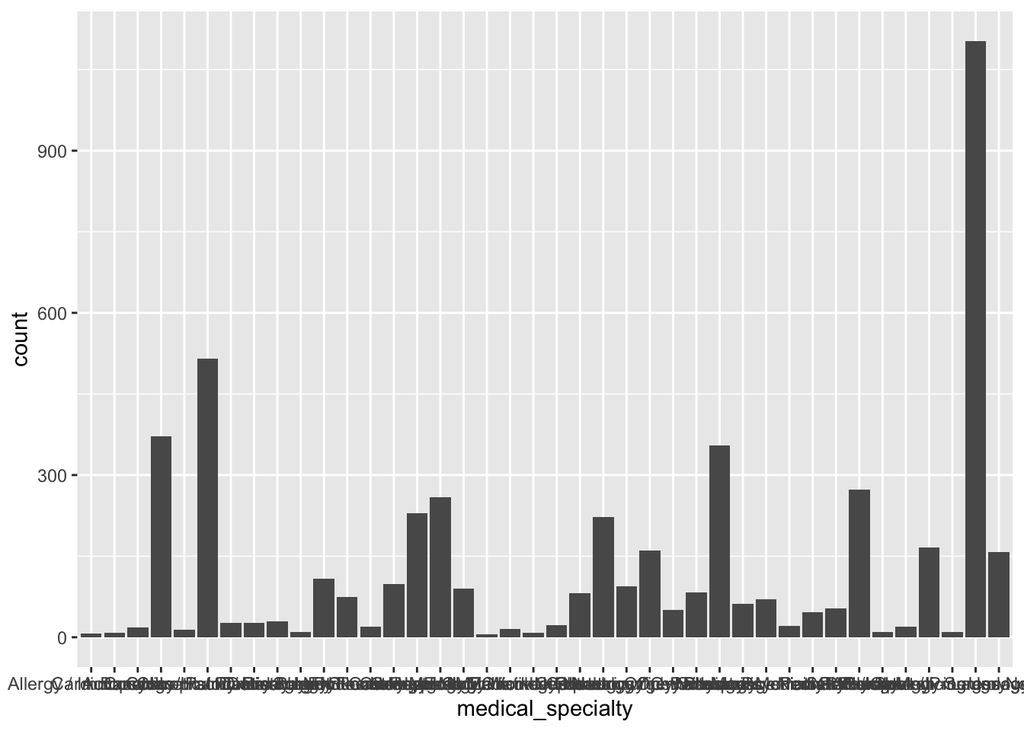

```r
ggplot(mt_samples, aes(x = medical_specialty)) +
    geom_bar()
```

There are 40 medical specialties and they are not normally distributed. Most frequent is simply surgery. Many specialties are related/overlapping, however I am confused as to why some specialties like “SOAP / Chart / Progress Note” are listed.

# Question 2

- Tokenize the the words in the transcription column
- Count the number of times each token appears
- Visualize the top 20 most frequent words
- Explain what we see from this result. Does it makes sense? What insights (if any) do we get?

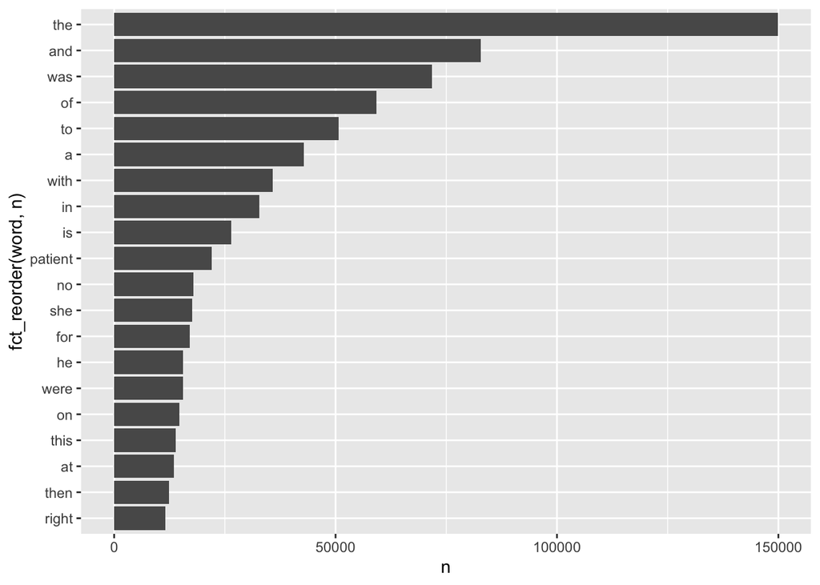

```r
mt_samples %>%
  unnest_tokens(word, transcription) %>%
  count(word, sort=TRUE) %>%
  top_n(20, n) %>%
  ggplot(aes(x = n, y = fct_reorder(word, n))) +
  geom_col()
```

All top 20 terms are stopwords I believe (must review list) except for patient.

# Question 3

- Redo visualization but remove stopwords before
- Bonus points if you remove numbers as well What do we see know that we have removed stop words? Does it give us a better idea of what the text is about?

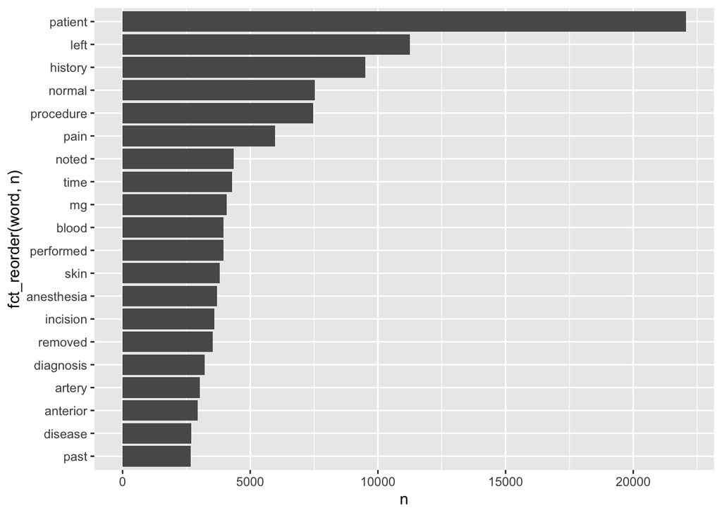

```r
mt_samples %>%
  unnest_tokens(word, transcription) %>%
   filter(!str_detect(word, "\\d")) %>%
   anti_join(stop_words, by = c("word"))%>%
  count(word, sort=TRUE) %>%
  top_n(20, n) %>%
  ggplot(aes(x = n, y = fct_reorder(word, n))) +
  geom_col()
```

After removing stopwords and numbers the top terms often reveal what could be performed to the patient, espeially surgery. Based on these terms they could reveal a lot of standard medical precudures done to address pain/health issues n patients across specialties.

# Question 4

repeat question 2, but this time tokenize into bi-grams. how does the result change if you look at tri-grams?

bigrams:

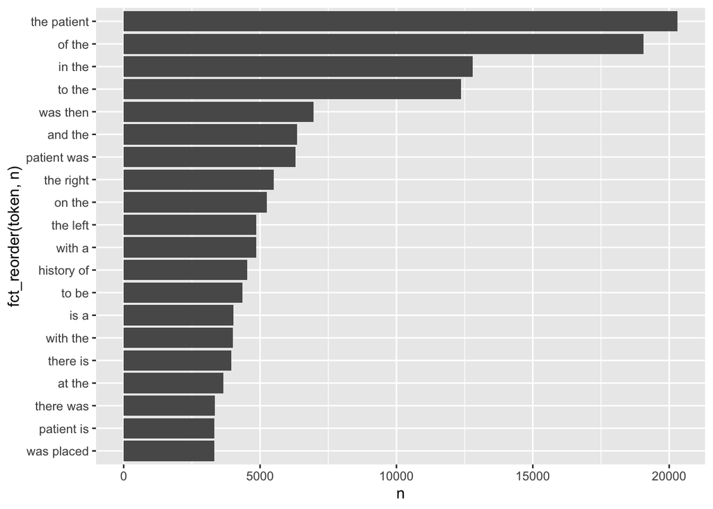

```r
mt_samples %>%
  unnest_ngrams(token, transcription, n = 2) %>%
  count(token, sort=TRUE) %>%
  top_n(20, n) %>%
  ggplot(aes(x = n, y = fct_reorder(token, n))) +
  geom_col()
```

trigrams:

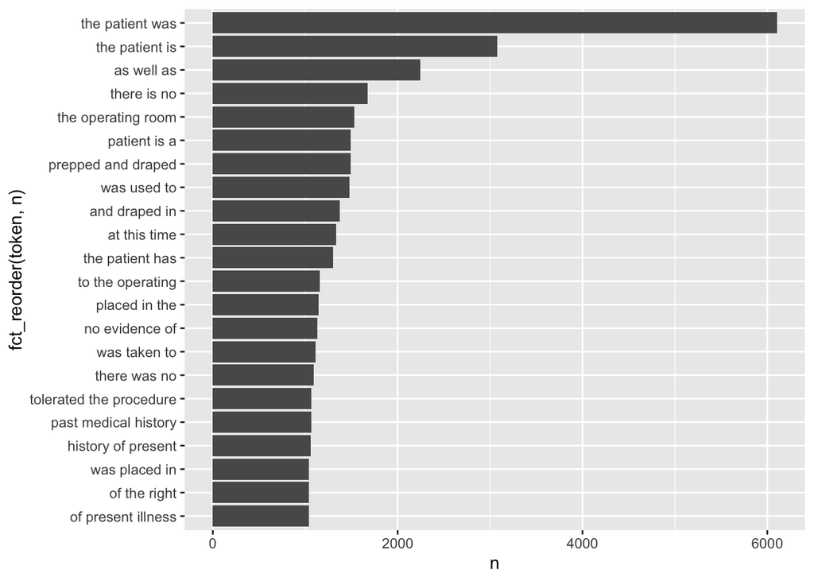

```r
mt_samples %>%
  unnest_ngrams(token, transcription, n = 3) %>%
  count(token, sort=TRUE) %>%
  top_n(20, n) %>%
  ggplot(aes(x = n, y = fct_reorder(token, n))) +
  geom_col()
```

All imply that something was going on with a patient- their status, what is being done to them, ….

# Question 5

Using the results you got from questions 4. Pick a word and count the words that appears after and before it.

Chosen word: *patient*

```r
#before
mt_samples |>
  unnest_ngrams(ngram, transcription, n=2) |>
  separate(ngram, into=c("word1", "word2", sep=" ")) |>
  select(word1, word2) |>
  filter(word1 == "patient") |>
  count(word2, sort=TRUE)
```

```
# A tibble: 588 × 2
   word2         n
   <chr>     <int>
 1 was        6293
 2 is         3332
 3 s          2143
 4 has        1417
 5 tolerated   994
 6 had         888
 7 will        616
 8 denies      552
 9 and         377
10 states      363
# ℹ 578 more rows
```

```r
#after
mt_samples |>
  unnest_ngrams(ngram, transcription, n=2) |>
  separate(ngram, into=c("word1", "word2", sep=" ")) |>
  select(word1, word2) |>
  filter(word2 == "patient") |>
  count(word1, sort=TRUE)
```

```
# A tibble: 279 × 2
   word1         n
   <chr>     <int>
 1 the       22312
 2 this        509
 3 history     106
 4 a            67
 5 and          51
 6 with         46
 7 procedure    32
 8 female       28
 9 to           28
10 use          24
# ℹ 269 more rows
```

# Question 6

Which words are most used in each of the specialties. you can use group_by() and top_n() from dplyr to have the calculations be done within each specialty. Remember to remove stopwords. How about the most 5 used words?

```r
mt_samples %>%
  unnest_tokens(word, transcription) %>%
  anti_join(stop_words, by = c("word")) %>% # removes stopwords
  filter(!str_detect(word, "\\d+")) %>% # removes numbers
  group_by(medical_specialty) %>%
  count(word, sort = TRUE) %>%
  top_n(1, n) %>%
  arrange(medical_specialty) # arranges by medical specialty
```

```
# A tibble: 42 × 3
# Groups:   medical_specialty [40]
   medical_specialty          word        n
   <chr>                      <chr>   <int>
 1 Allergy / Immunology       history    38
 2 Autopsy                    left       83
 3 Bariatrics                 patient    62
 4 Cardiovascular / Pulmonary left     1550
 5 Chiropractic               pain      187
 6 Consult - History and Phy. patient  3046
 7 Cosmetic / Plastic Surgery patient   116
 8 Dentistry                  patient   195
 9 Dermatology                patient   101
10 Dermatology                skin      101
# ℹ 32 more rows
```

```r
mt_samples %>%
  unnest_tokens(word, transcription) %>%
  anti_join(stop_words, by = c("word")) %>% # remove stopword
  filter(!str_detect(word, "\\d+")) %>% # remove number
  group_by(medical_specialty) %>%
  count(word, sort = TRUE) %>%
  top_n(5, n) %>%
  arrange(medical_specialty)
```

```
# A tibble: 210 × 3
# Groups:   medical_specialty [40]
   medical_specialty    word          n
   <chr>                <chr>     <int>
 1 Allergy / Immunology history      38
 2 Allergy / Immunology noted        23
 3 Allergy / Immunology patient      22
 4 Allergy / Immunology allergies    21
 5 Allergy / Immunology nasal        13
 6 Allergy / Immunology past         13
 7 Autopsy              left         83
 8 Autopsy              inch         59
 9 Autopsy              neck         55
10 Autopsy              anterior     47
# ℹ 200 more rows
```

# Question 7 - Extra

Find your own insight in the data:

Ideas:

- Interesting ngrams
- See if certain words are used more in some specialties then others

```r
# tf:  and and idf - important words

mt_samples %>%
  unnest_tokens(text, transcription) %>%
  count(text, medical_specialty) %>%
  bind_tf_idf(text, medical_specialty, n) %>%
  arrange(desc(tf_idf))
```

```
# A tibble: 164,715 × 6
   text         medical_specialty            n      tf   idf  tf_idf
   <chr>        <chr>                    <int>   <dbl> <dbl>   <dbl>
 1 carbohydrate Diets and Nutritions        37 0.00904 2.30  0.0208
 2 reactivity   Lab Medicine - Pathology     7 0.00360 3.00  0.0108
 3 calories     Diets and Nutritions        24 0.00586 1.61  0.00943
 4 tumor        Lab Medicine - Pathology    35 0.0180  0.470 0.00847
 5 meal         Diets and Nutritions        26 0.00635 1.29  0.00820
 6 tooth        Dentistry                  108 0.00763 1.05  0.00801
 7 linguistic   Speech - Language           13 0.00343 2.30  0.00789
 8 lymph        Lab Medicine - Pathology    30 0.0154  0.511 0.00789
 9 designated   Lab Medicine - Pathology     5 0.00257 3.00  0.00771
10 lobe         Lab Medicine - Pathology    29 0.0149  0.511 0.00762
# ℹ 164,705 more rows
```